# Präsentation Project Head and Neck Cancer

Nils Mechtel, Tobias Hub, Niklas Urbanek, Pascal Poc

24 July 2019

# Predicting Cancer-Specific Vulnerability via DAISY System

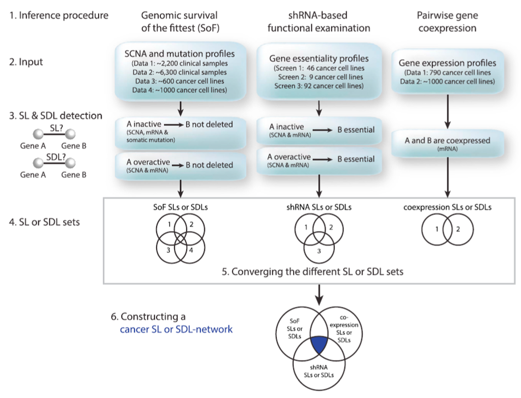

Figure 1 | Daisy-Workflow

# Milestones

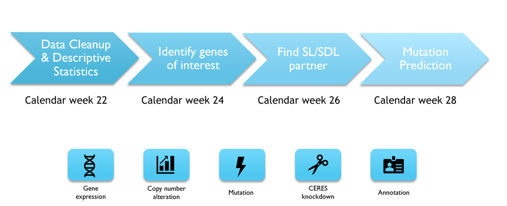

Figure 2 | Milestones of our project

# Identify genes of interest

## k-means clustering of CNA and expression data with normalized values(-reference) for SDL GOI

To find potential genes for SDL pair detection, clustering through k-means was executed.

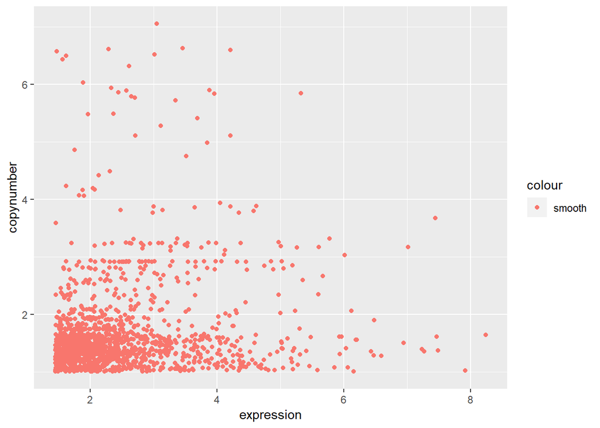

```r
km.genes = Reduce(intersect, list(rownames(expression.HNC), rownames(copynumber.HNC))) # Intersect set of expression and CNA

# Create data rame with expression and CNA values
km.expression = expr.HNC.norm[km.genes,]
km.copynumber = cna.HNC.norm[km.genes,]
km.data = lapply(1:length(ID), function(x) {
  out = data.frame(genes =km.genes, expression = km.expression[,x], copynumber = km.copynumber[,x])
  return (out)
})
# Combine rows for k mean clustering
comb.ex.cna = do.call(rbind, km.data)
comb.ex.cna = comb.ex.cna[which(comb.ex.cna$copynumber >= 1 & comb.ex.cna$expression >=quantile(comb.ex.cna$expression,0.95)),]

# Plotting of normalized expression valuess against CNA data for a short overview.
ggplot(comb.ex.cna[, 2:3],
       aes(x = expression, y = copynumber, color = "smooth")) +
  geom_point()
```

To check the perfect ammount of clusters in k-means, an ellbow test was implemented.

```r
# Ellbow method to find optimal ammount of clusters
emp = vector() # Create an empty vector
for (i in 1:10) emp[i] = sum(kmeans(comb.ex.cna[2:3], i)$withinss) # Calculate the sum within squared values for 10 clusters
emp # Look at the sum within squares for 10 clusters
```

```
 [1] 2607.5505 1461.2845  927.0961  705.1163  527.8536  415.6683  350.4004
 [8]  307.2061  273.1408  249.8811
```

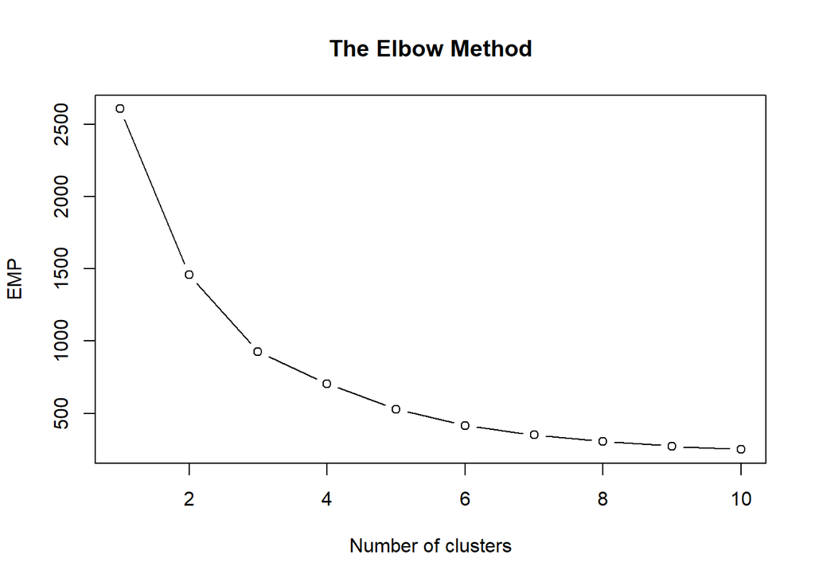

```r
# Plotting of Ellbow method
plot(1:10,
     emp,
     type = 'b',
     main = paste('The Elbow Method'),
     xlab = 'Number of clusters',
     ylab = 'EMP')
```

Result: The ellbow test shows that 3 clusters are sufficient.

K-means were executed and plotted. Afterwards the potential SDL candidates were identified through higher expression values.

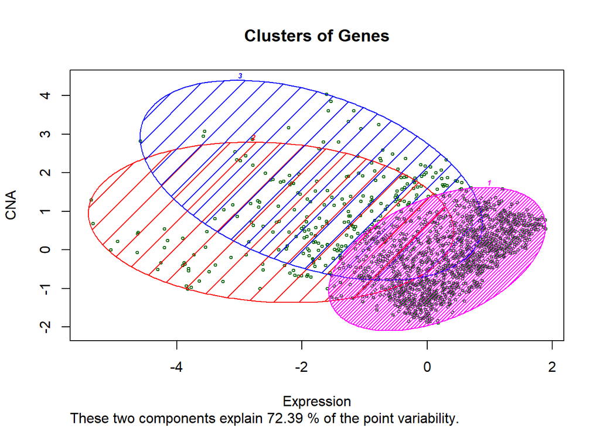

```r
# Fitting K-Means to the dataset
kmeans = kmeans(x = comb.ex.cna[,2:3], centers = 3,iter.max = 1000, nstart = 1) # See elbow method (k = 3)
y_kmeans = kmeans$cluster

# Visualising the clusters
clusplot(comb.ex.cna,
         y_kmeans,
         lines = 0,
         shade = TRUE,
         color = TRUE,
         labels = 4,
         plotchar = FALSE,
         span = TRUE,
         stand = FALSE,
         cex =0.5,
         main = paste('Clusters of Genes'),
         xlab = 'Expression',
         ylab = 'CNA')
```

The Plot “Cluster of genes” features the 3 clusters of values from expression and CNA data. Due to little variance between the data pairs, the intersection set is comparatively big.

In order to define SDL candidates, the cluster with highest expression values was chosen and filtered again according to expression numbers.

```r
comb.ex.cna = cbind(comb.ex.cna, y_kmeans)# Combine kmeans with genes
# Sort comb.ex.cna data decresing for selecting adequate number of cluster
comb.ex.cna = comb.ex.cna[order(comb.ex.cna$expression,decreasing =TRUE),]

# Filtering of the most expressed and alterated genes
goi.sdl = comb.ex.cna[which(comb.ex.cna$y_kmeans == comb.ex.cna[1,4]),]

# Sort dataframe
goi.sdl = goi.sdl[order(goi.sdl$expression,decreasing=TRUE),]
kable(goi.sdl[1:5,])
```

|  | genes | expression | copynumber | y_kmeans |
| --- | --- | --- | --- | --- |
| 428012 | DSG3 | 8.237872 | 1.641760 | 3 |
| 41915 | FXYD3 | 7.914724 | 1.022479 | 3 |
| 33343 | CST6 | 7.484452 | 1.372464 | 3 |
| 185157 | F3 | 7.466245 | 1.610442 | 3 |
| 354894 | FOXE1 | 7.447917 | 3.676721 | 3 |

```r
goi.SDL = as.character(goi.sdl$genes[1:5])
```

## Investigate high frequencies of deleterious mutations SL GOI

Create a dataframe with data for the heatmap.

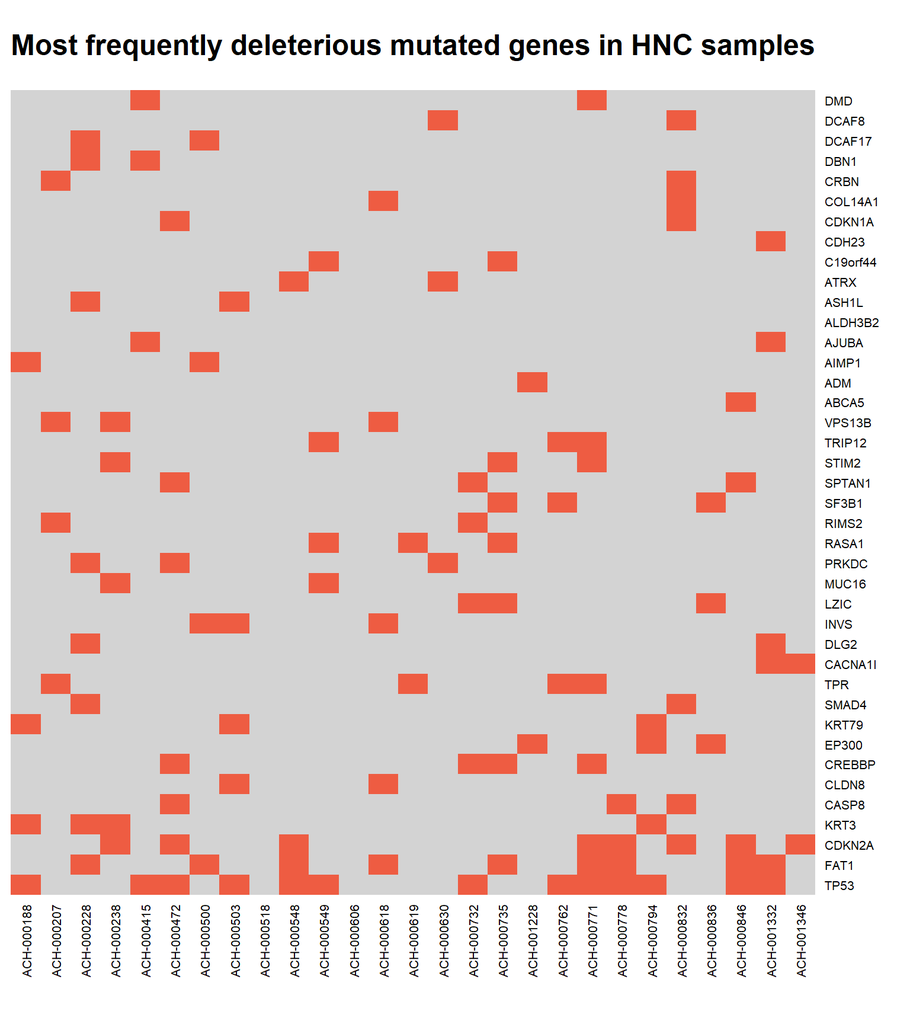

```r
mutation.HNC.df = do.call(rbind, mutation.HNC) # All mutation data of HNC samples in one dataframe
heatmap.genes = as.data.frame(table(mutation.HNC.df$Hugo_Symbol)) # Dataframe with all mutated genes in HNC samples just once

heatmap.data = as.data.frame(sapply(1:(length(ID)), function(a) {
  out = ifelse(heatmap.genes$Var1 %in% mutation.HNC[[a]]$Hugo_Symbol, 1, 0) # Per HNC sample: every gene which is mutated gets a 1, otherwise a 0
  return(out)
}))

# Define row and column names
rownames(heatmap.data) = heatmap.genes$Var1
colnames(heatmap.data) = ID

# Order from high to low frequency
heatmap.data$sum = apply(heatmap.data, 1, sum)
heatmap.data = heatmap.data[order(-heatmap.data$sum), 1:27]

# Heatmap of the most frequently deleterious mutated genes in HNC samples
heatmap(data.matrix(heatmap.data)[1:40,],
        Rowv=NA,
        Colv=NA,
        col = c("lightgrey", "tomato2"),
        scale="column",
        cexRow = 0.8,
        cexCol = 0.8,
        main = "Most frequently deleterious mutated genes in HNC samples")
```

Result: TP53, FAT1, CDKN2A, KRT3 and CASP8 are the 5 most frequently deleterious mutated genes in our HNC samples.

According to Leemans et al. (2018) these are frequent mutations in HNC:

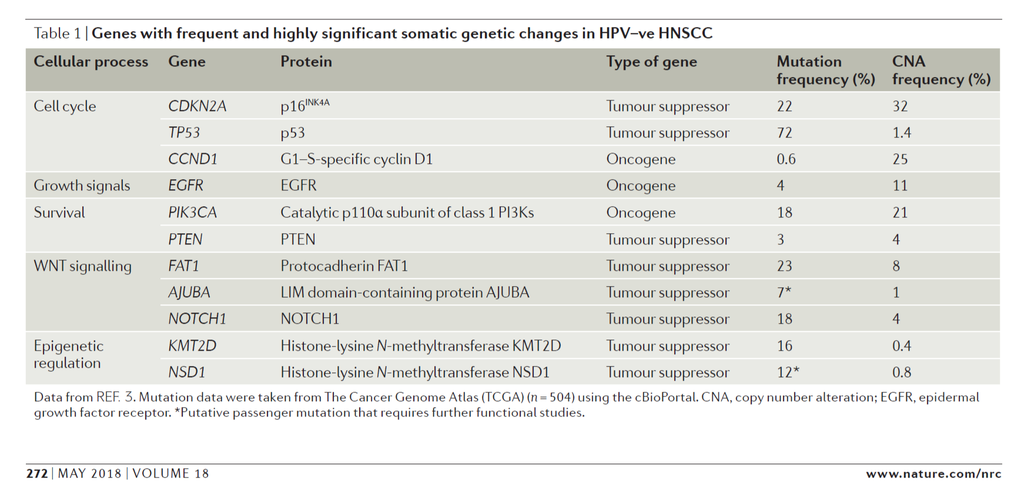

Leemans, C. R. et al. (2018). The molecular landscape of head and neck cancer. Nat. Rev. Cancer 18, 269-282.

Compare our SL GOI with genes from literature.

```r
# create dataframe with goi from literature
goi.lit = data.frame(Gene = c("CDKN2A", "TP53", "CCND1", "EGFR", "PIK3CA", "PTEN", "FAT1", "AJUBA", "NOTCH1", "KMT2D", "NSD1"),
                     "Mutation frequency" = c(22, 72, 0.6, 4, 18, 3, 23, 7, 18, 16, 12),
                     "CNA frequency" = c(32, 1.4, 25, 11, 21, 4, 8, 1, 4, 0.4, 0.8))

heatmap_position = sapply(1:nrow(goi.lit), function(a) { # Search for the position of goi.lit in mutated genes of HNC samples
  position = which(rownames(heatmap.data) == goi.lit$Gene[a])
  if(length(position) == 0) {position = NA} # If gene is not part of the genes mutated in HNC samples its position is replaced with NA
  return(position)
})

goi.lit$"Heatmap position" = heatmap_position # Add heatmap position to goi.lit
rownames(goi.lit) = goi.lit$Gene
goi.lit$Gene = NULL
goi.lit = goi.lit[order(goi.lit$"Heatmap position"),]
kable(goi.lit) # Show a table of goi.lit
```

|  | Mutation.frequency | CNA.frequency | Heatmap position |
| --- | --- | --- | --- |
| TP53 | 72.0 | 1.4 | 1 |
| FAT1 | 23.0 | 8.0 | 2 |
| CDKN2A | 22.0 | 32.0 | 3 |
| AJUBA | 7.0 | 1.0 | 28 |
| KMT2D | 16.0 | 0.4 | 66 |
| NOTCH1 | 18.0 | 4.0 | 82 |
| NSD1 | 12.0 | 0.8 | 715 |
| CCND1 | 0.6 | 25.0 | NA |
| EGFR | 4.0 | 11.0 | NA |
| PIK3CA | 18.0 | 21.0 | NA |
| PTEN | 3.0 | 4.0 | NA |

Because our most frequent mutated genes almost aproximately match with frequent mutations from literature we choose the 5 genes with most frequent mutations in HNC samples.

```r
goi.SL = rownames(heatmap.data)[1:5]
goi.SL
```

```
[1] "TP53"   "FAT1"   "CDKN2A" "KRT3"   "CASP8"
```

# Find SL/SDL partner

## SL/SDL partner search following the daisy model

To examine gene pairs A and B which fulfill the criteria of SoF and functional examination we performe a Wilcoxon rank sum test on copynumber or CERES knockdown data. We have 5 inactive genes (goi.SL) and 5 overactive genes (goi.SDL) which are defined as genes A. The Wilcoxon rank sum test now returns all genes B which pass the test in a significant manner (p<0.05).

```r
'Daisy.Wilcox' = function(input_genes,input_data, inactive_overactive, less_greater){
  Daisy_Wilcox = lapply(1:length(input_genes), function(m) {
  goi = input_genes[m] # Set 1 of 5 goi
  # Depending on SL or SDL partner search gene B needs to be inactive (SL) or overactive (SDL)
  if(inactive_overactive == 1) { # inactive_overactive == 1 chooses overactive
    mean.exp.goi = mean(t(expression[goi,]))
    exp.goi.norm = expression[goi,] - mean.exp.goi # Normalised expression values of goi
    mut_overa.ID = lapply(1:ncol(expression), function(a) {
    out = if(exp.goi.norm[goi, a] > 0 & copynumber[goi,a] > 0.3) {a} else {NA} # Filter all IDs which are overactive: overexpressed and CNA > 0,3
    return(out)
    })
  } else { # inactive_overactive == 0 chooses inactive
    mut_overa.ID = lapply(1:length(mutation), function(a) {
    out = ifelse(goi %in% mutation[[a]]$Hugo_Symbol, a, NA) # Filter all IDs which have a mutation of goi
    return(out)
    })
  }

  not_mut_overa.ID = grep("NA", mut_overa.ID) # ID of samples which have NO inactivity/overactivity of goi
  mut_overa.ID = as.integer(mut_overa.ID[is.na(mut_overa.ID) == FALSE]) # ID of samples which HAVE inactivity/overactivity of goi

  p.value = sapply(1:nrow(input_data), function(b) {
    mut_overa.data = t(input_data[b, mut_overa.ID])
    not_mut_overa.data = t(input_data[b, not_mut_overa.ID])
    if (less_greater == 1) {
      p = wilcox.test(mut_overa.data, not_mut_overa.data, alternative = "greater")$p.value # One sided (greater) Wilcoxon Sum Rank Test
    } else {
      p = wilcox.test(mut_overa.data, not_mut_overa.data, alternative = "less")$p.value # One sided (greater) Wilcoxon Sum Rank Test
    }

  })

  out = data.frame(genes = rownames(input_data), p_value = p.value)
  out = out[which(out$p_value < 0.05),]
  return(out)
  })
  names(Daisy_Wilcox) = input_genes
  return(Daisy_Wilcox)
}
```

To examine gene pairs A and B which fulfill the criteria of gene co expresssion we performe a Spearman correlation test on the expression data. We have 5 inactive genes (goi.SL) and 5 overactive genes (goi.SDL) which are defined as genes A The correlation test now returns all genes B that correlate to gene A in a significant manner (p<0.05).

```r
'Daisy.Spearman' = function(input_genes){
  Daisy_Spearman = lapply(1:length(input_genes), function(m) { # Build up a list with the 5 goi; lapply: goes through the code for each gene A
  goi = input_genes[m]

  p.value = sapply(1:nrow(expression), function(a){  # Creation of a list with the length of the expression data, for the reacent goi, go through every gene and calculate cor.test
    expression.goi =t(expression[goi,])           # Variable containing expressiondata of the goi (gene A)
    expression.GeneB =t(expression[a,])           # Variable containing all other genes (gene B)
    p = cor.test(expression.goi,expression.GeneB, alternative = "greater", method = "spearman", exact = FALSE)$p.value # One sided spearman correlation test
  })

  # Return a dataframe with the columns genes(HugoSymbols) and p_values (p.values)
  out = data.frame(genes = rownames(expression), p_value = p.value)
  out = out[which(out$p_value < 0.05),] # Filter for significant p.values
  out = out[which(out$genes != goi),]   # Select onl these wich are not the same gene as the goi (would be a corr of 1)
  return(out)
  })
  names(Daisy_Spearman) = input_genes
  return(Daisy_Spearman)
}
```

Both functions return a list, which contains the five genes of interest, each containing a dataframe with all genes examined as potential SL/SDL partners plus their calculated p-values.

### SL-parter

SoF:

```r
SL.SoF = Daisy.Wilcox(goi.SL, copynumber, inactive_overactive = 0, less_greater = 1) # SoF, inactive, one sided Wilcoxon rank test, alternative = "greater"
head(SL.SoF[[1]]) # Example of SL SoF for first GOI (TP53)
```

```
        genes    p_value
10    NAALAD2 0.01270171
88   NAALADL1 0.01787355
105    MCTS2P 0.01801226
109  SNORD119 0.03415298
120 SNORD111B 0.04370297
148    MIR875 0.02447163
```

Functional examination:

```r
SL.functional.examination = Daisy.Wilcox(goi.SL, kd.ceres, inactive_overactive = 0, less_greater = 0) # Functional examination, inactive, one sided Wilcoxon rank test, alternative = "less"
head(SL.functional.examination[[1]]) # Example of SL functional examination for first GOI (TP53)
```

```
     genes     p_value
10   AADAC 0.008677123
21    AAR2 0.016419751
70   ABCG1 0.010374932
100   ABL2 0.042951952
149   ACN9 0.006751253
211 ACTR1B 0.010514096
```

Gene coexpression:

```r
SL.coexpression = Daisy.Spearman(goi.SL)
head(SL.coexpression[[1]]) # Example of SL coexpression for first GOI (TP53)
```

```
      genes      p_value
4     SCYL3 7.196232e-06
5  C1orf112 2.516883e-04
10     NFYA 2.641665e-09
13    LAS1L 3.844908e-02
17   ANKIB1 1.345544e-02
24     CD99 8.535496e-03
```

### SDL-parter

SoF:

```r
SDL.SoF = Daisy.Wilcox(goi.SDL, copynumber, inactive_overactive = 1, less_greater = 1) # SoF, overactive, one sided Wilcoxon rank test, alternative = "greater"
```

Functional examination:

```r
SDL.functional.examination = Daisy.Wilcox(goi.SDL, kd.ceres, inactive_overactive = 1, less_greater = 0) # Functional examination, overactive, one sided Wilcoxon rank test, alternative = "less"
```

Gene coexpression:

```r
SDL.coexpression = Daisy.Spearman(goi.SDL)
```

## Converging the different SL and SDL sets

Define function to converge SL/SDL sets.

```r
'partner' = function(input_genes, SoF, functional.examination, coexpression){
  partner = lapply(1:length(input_genes), function(a) {
    dat_picker.SoF = SoF[[a]]
    dat_picker.functional_examination = functional.examination[[a]]
    dat_picker.coexpression = coexpression[[a]]
    partnergenes = Reduce(intersect, list(dat_picker.SoF$genes, dat_picker.functional_examination$genes, dat_picker.coexpression$genes)) # Intersect of genes from all three tests
    out = data.frame(genes = partnergenes, # Column with reduced genes
                     SoF = dat_picker.SoF[which(dat_picker.SoF$genes %in% partnergenes),"p_value"], # Column with p value from SoF
                     functional_examination = dat_picker.functional_examination[which(dat_picker.functional_examination$genes %in% partnergenes),"p_value"], # Column with p value from functional examination
                     coexpression = dat_picker.coexpression[which(dat_picker.coexpression$genes %in% partnergenes),"p_value"]) # Column with p value from coexpression
    return(out)
  })
  names(partner) = input_genes
  return(partner)
}
```

Converge different sets.

```r
SL.partner = partner(goi.SL, SL.SoF, SL.functional.examination, SL.coexpression)
SDL.partner = partner(goi.SDL, SDL.SoF, SDL.functional.examination, SDL.coexpression)
kable(data.frame("SL genes" = names(SL.partner),
           "SL number of partner" = sapply(1:length(SL.partner), function(a){nrow(SL.partner[[a]])}),
           "SDL genes" = names(SDL.partner),
           "SDL number of partner" = sapply(1:length(SDL.partner), function(a){nrow(SDL.partner[[a]])})
           ))
```

| SL.genes | SL.number.of.partner | SDL.genes | SDL.number.of.partner |
| --- | --- | --- | --- |
| TP53 | 21 | DSG3 | 96 |
| FAT1 | 54 | FXYD3 | 78 |
| CDKN2A | 60 | CST6 | 232 |
| KRT3 | 124 | F3 | 78 |
| CASP8 | 22 | FOXE1 | 136 |

## Plotting networks of the Interactions

Creation of a function for transforming given data into a format iGraph can work with and plotting of the network.

```r
'network' = function(X.partner,width,node.color,frame.color,node.size,Titel,label,GOI){ # (SL/SDL.partner,number,string,string,number,string,NA oder names(plot))

  color.vector = c("darkred", "darkgreen", "turquoise", "yellow", "orange") # Define colours
  # Transform data into a dataframe with 3 colums for each GOI
  edgelist = lapply(1:length(X.partner), function(a){
    dat_picker = X.partner[[a]]
    edge.list = data.frame(Gene.A = names(X.partner)[a], Gene.B = dat_picker$genes, colours = color.vector[a]) # 3 columns
  })
  edge.list = do.call(rbind, edgelist) # Combine all goi-dataframes to one.

  edge.list$colours = as.character(edge.list$colours) # After the lapply, column "colours" has class 'factor'. For the plottingfunction it must be character

  net = graph_from_data_frame(edge.list, directed = T) # Tranform the dataframe into an iGraph object
  layout1 = layout_with_kk(net)                        # Given layout

  # Plotting parameters are defined. vertex= Genes edges = interactions
  plot(net, layout = layout1, rescale = T,
       ylim = c(-0.9,1),
       xlim = c(-0.1,-0.1),
       edge.color = edge.list$colours,
       edge.width = width,
       edge.arrow.mode = 0,
       vertex.color = node.color,
       vertex.frame.color = frame.color,
       vertex.size = node.size,
       vertex.label.font = 2,
       vertex.label.color = "black",
       vertex.label = label,
       margin = 0.1)

  # Add legend to the graph
  legend (x = 1.2,
          y = 1, GOI,
          fill = c("darkred", "darkgreen", "turquoise", "yellow", "orange"))

  # Add titel to the graph
  title(Titel,cex.main=3,col.main="black ")

}
```

Creating a networkplot for the SL-partner.

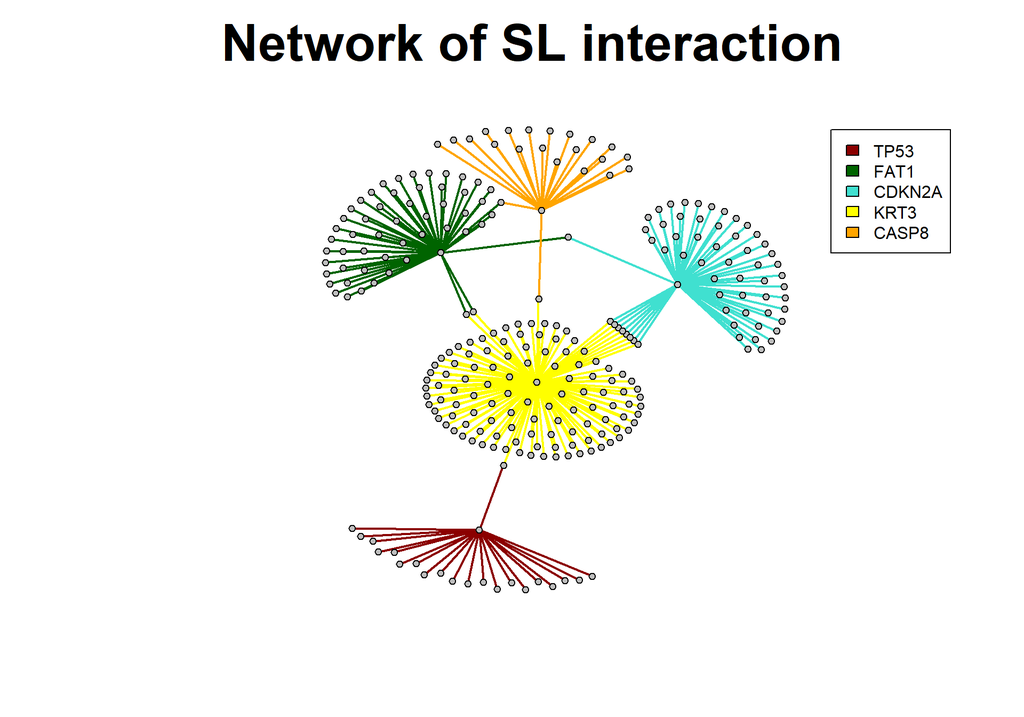

```r
network(SL.partner,2,"grey","black",3,"Network of SL interaction", NA, goi.SL )
```

Creating a network for the SDL-partner.

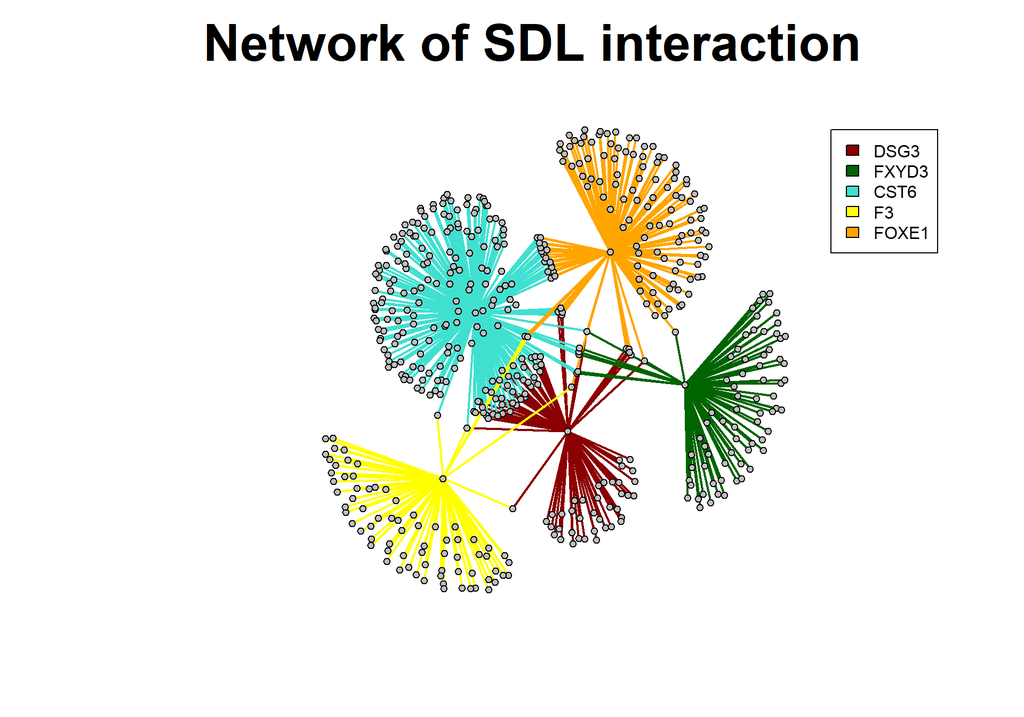

```r
network(SDL.partner,2,"grey","black",3,"Network of SDL interaction", NA, goi.SDL )
```

Because there are to many SL/SDL partner to plot a network we reduce SL/SDL partner to the most significants. To do so, we reduce the number of partner genes for better plotting without removing genes which are connected to more than one GOI.

```r
'reduce.partner' = function(list){
  reduced_partner = lapply(1:length(list), function(a){ # Go through every element of SL/SDL partner
    dat_picker = list[[a]]

    if (nrow(dat_picker) > 20) { # (1) If length of dat_picker is larger than 20 reduce to the 20 most significant plus the genes we want to keep

      dat_picker$order = apply(dat_picker[,2:4], 1, mean) # Create an extra column with the mean p value of all 3 tests
      ordered_data = dat_picker[order(dat_picker$order),][,1:4] # Order the partner genes after this mean value from most to least significant p value

      gene_intersect = lapply(1:length(list), function(b){
          as.list(Reduce(intersect, list(dat_picker$genes), list[[b]]$genes)) # Search for genes that are partner for more than one GOI
      })
      gene_intersect[a] = NULL # Remove intersect of the GOI partner genes with itself
      keep_genes = c(gene_intersect[[1]], gene_intersect[[2]], gene_intersect[[3]], gene_intersect[[4]]) # Combine all the genes in a list
      position = sapply(1:length(keep_genes), function(c){
        which(as.character(ordered_data$genes) == keep_genes[c])
      })
      position = position[which(position > 20)] # Partner genes that are already in the first 20 genes don´t need to be chosen

      if(length(position) > 3) {position = position[1:3]} # If there are still more than 3 extra genes only choose the first 5
      out = ordered_data[c(1:20, position),]
      return(out) # Return reduced data
    } else {
      return(ordered_data) # (2) If length of dat_picker is smaller than 20 return data unreduced
    }
  })
  names(reduced_partner) = names(list)
  return(reduced_partner)
}
```

Reduce SL.parter/SDL.partner to the most significant.

```r
SL.partner.reduced = reduce.partner(SL.partner)
SDL.partner.reduced = reduce.partner(SDL.partner)

kable(data.frame("SL genes" = names(SL.partner),
           "SL partner" = sapply(1:length(SL.partner.reduced), function(a){nrow(SL.partner.reduced[[a]])}),
           "SDL genes" = names(SDL.partner),
           "SDL partner" = sapply(1:length(SDL.partner.reduced), function(a){nrow(SDL.partner.reduced[[a]])})
           ))
```

| SL.genes | SL.partner | SDL.genes | SDL.partner |
| --- | --- | --- | --- |
| TP53 | 20 | DSG3 | 23 |
| FAT1 | 21 | FXYD3 | 23 |
| CDKN2A | 22 | CST6 | 23 |
| KRT3 | 23 | F3 | 23 |
| CASP8 | 20 | FOXE1 | 23 |

Now the number of SL/SDL partner is much better to plot.

## Plotting SL/SDL partner network with reduced number of partner.

SL interaction plot with reduced partners.

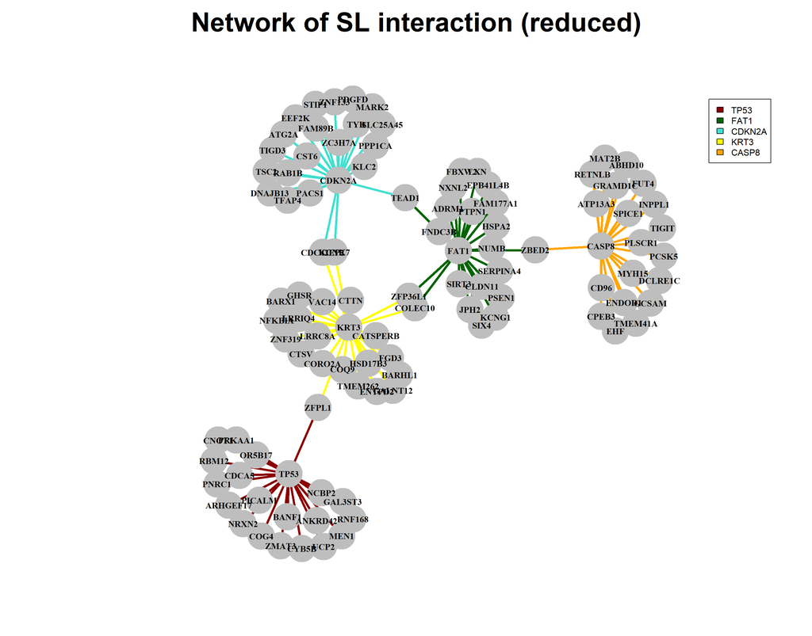

```r
network(SL.partner.reduced,4,"grey","grey",12,"Network of SL interaction (reduced)", names(plot), goi.SL)
```

SDL interaction plot with reduced partners.

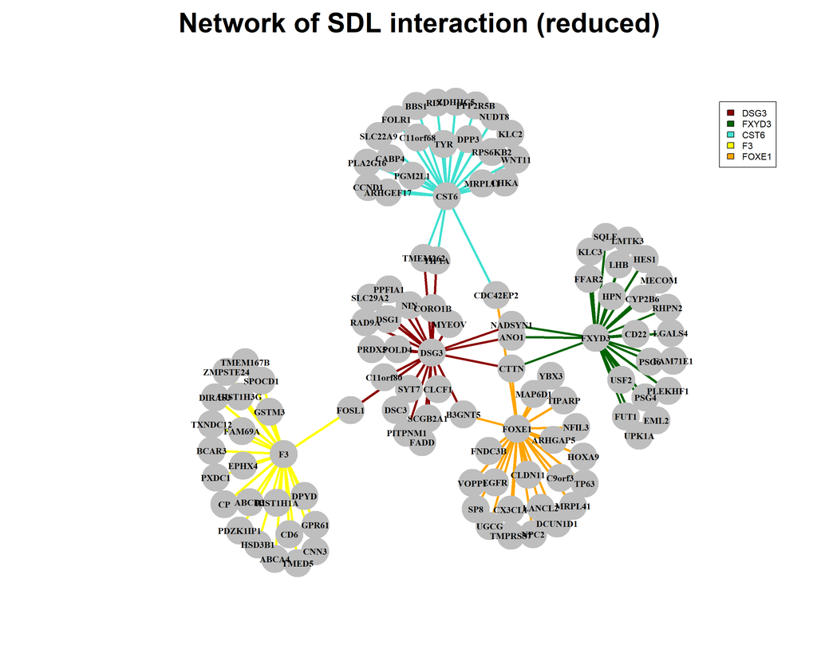

```r
network(SDL.partner.reduced,4,"grey","grey",12,"Network of SDL interaction (reduced)", names(plot),goi.SDL)
```

# References

## Articles

1.) Jerby-Arnon, L., et al. (2014). “Predicting Cancer-Specific Vulnerability via Data-Driven Detection of Synthetic Lethality.” Cell 158(5): 1199-1209. 2.) Ashworth, A., et al. (2011). “Genetic Interactions in Cancer Progression and Treatment.” Cell 145(1): 30-38. 3.) O’Neil, N. J., et al. (2017). “Synthetic lethality and cancer.” Nature Reviews Genetics 18: 613.